# team.Rmd (ds202_lab3)

Anthony Song, github: aasong113, Jaydon Cobb, github: JaydonLCobb

```r
# importing libraries
library(ggplot2)
library(dplyr)
library(readxl)
# setting dat and column names
dat <- readxl::read_xls('GSS.xls')
names(dat) <- c("year", "ID_NUM", "marital_status", "sex", "political_affil", "happiness", "ballot_used")
print(dat)
```

```
## # A tibble: 64,816 x 7
##     year ID_NUM marital_status sex    political_affil  happiness   ballot_used
##    <dbl>  <dbl> <chr>          <chr>  <chr>            <chr>       <chr>
##  1  1972      1 Never married  Female Ind,near dem     Not too ha… Not applicab…
##  2  1972      2 Married        Male   Not str democrat Not too ha… Not applicab…
##  3  1972      3 Married        Female Independent      Pretty hap… Not applicab…
##  4  1972      4 Married        Female Not str democrat Not too ha… Not applicab…
##  5  1972      5 Married        Female Strong democrat  Pretty hap… Not applicab…
##  6  1972      6 Never married  Male   Ind,near dem     Pretty hap… Not applicab…
##  7  1972      7 Divorced       Male   Ind,near dem     Not too ha… Not applicab…
##  8  1972      8 Never married  Male   Ind,near dem     Not too ha… Not applicab…
##  9  1972      9 Never married  Female Strong democrat  Pretty hap… Not applicab…
## 10  1972     10 Married        Female Strong democrat  Pretty hap… Not applicab…
## # … with 64,806 more rows
```

# Question 1

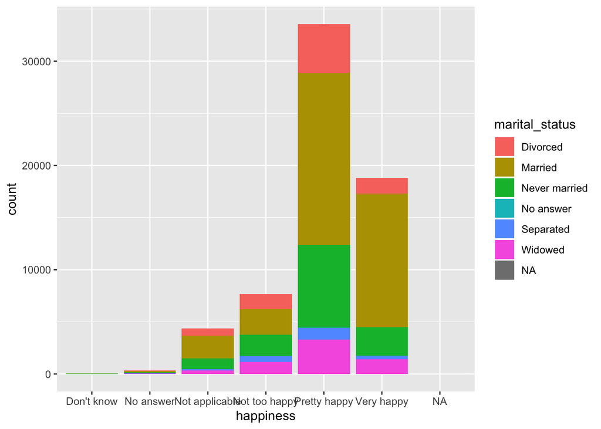

```r
plt <- ggplot(data=dat,  aes(x=happiness, fill=marital_status)) # assigning graph
plt + geom_bar() # makes the height of the bar proportional to the number of cases in each group
```

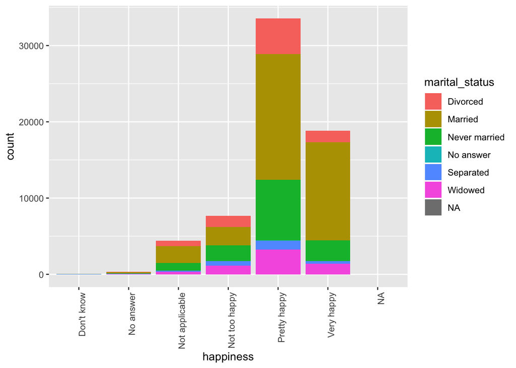

```r
pltNew <- plt + geom_bar()
pltNew + theme(axis.text.x=element_text(angle=90, hjust=1))
```

From my observations regarding the above graph, it appears that the majority of people that are happy (pretty/very) are married. Contrary to that, people in situations where they are seperated/widowed seem to have the smallest amounts of happy persons.

# Question 2

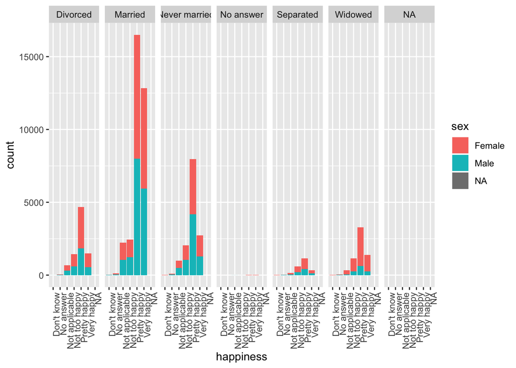

```r
plt <- ggplot(dat,aes(x=happiness,fill=sex))+geom_bar()+facet_grid(~marital_status) # assigning graph
plt + theme(axis.text.x=element_text(angle=90, hjust=1)) # rotating the x-axis labels 90 degrees
```

# Question 3

How does the happiness of a respondent relate to the political party affiliation? In the initial cleaning of the data I removed, “Don’t know” and values that were NA. I chose to use a fractional stacked bar chart so I could normalize the values to a percentage of the total. From this we see that the Strong republicans, not independent republicans, and Ind. near republicans displayed the most happiness. Being happy consisted of Pretty happy and Very happy. This can be confirmed by the summary table that was created by averaging the happiness when they were assigned a numeric value.

```r
dat3<-dat[!(dat$political_affil=="Don't know"),]


dat3 <- dat3[!(dat$happiness=="Not applicable"),]
```

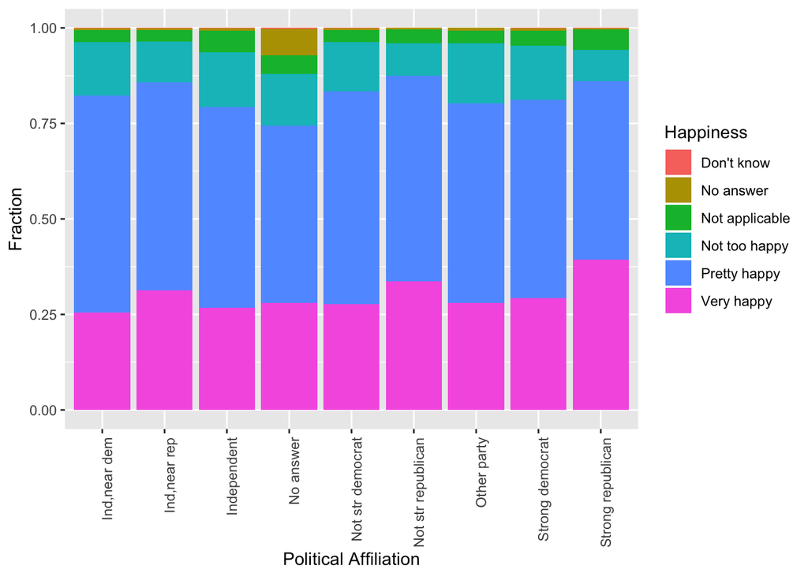

```r
dat3 <- dat3[!is.na(dat3$`happiness`), ]
dat3 <- dat3[!is.na(dat3$`political_affil`), ]

plt3 <- ggplot(data = dat3, aes(x=political_affil, fill=happiness)) + geom_bar(position="fill") + xlab("Political Affiliation") + labs(fill = "Happiness") + ylab("Fraction")
plt3+ theme(axis.text.x=element_text(angle=90, hjust=1))
```

```r
dat3 %>%
    mutate(quantitative_happiness = case_when(happiness == 'Very happy' ~ 3,
                                              happiness == 'Pretty happy' ~ 2,
                                              happiness == 'Not too happy' ~ 1,
                                              TRUE ~ 0)) %>%
  group_by(political_affil) %>%
    summarise(avg_happiness = mean(quantitative_happiness))
```

```
## # A tibble: 9 x 2
##   political_affil    avg_happiness
##   <chr>                      <dbl>
## 1 Ind,near dem                2.04
## 2 Ind,near rep                2.13
## 3 Independent                 2.00
## 4 No answer                   1.90
## 5 Not str democrat            2.07
## 6 Not str republican          2.17
## 7 Other party                 2.04
## 8 Strong democrat             2.06
## 9 Strong republican           2.19
```

# Question 4

# 4.1)

How does the year affect the marital status?

From this fractional stacked bar chart, we can draw the conclusion that the fraction of people married decreases, and the fraction of people divorced increases. This can be interpreted as the change from social values and norms that are developed and integrated into western culture.

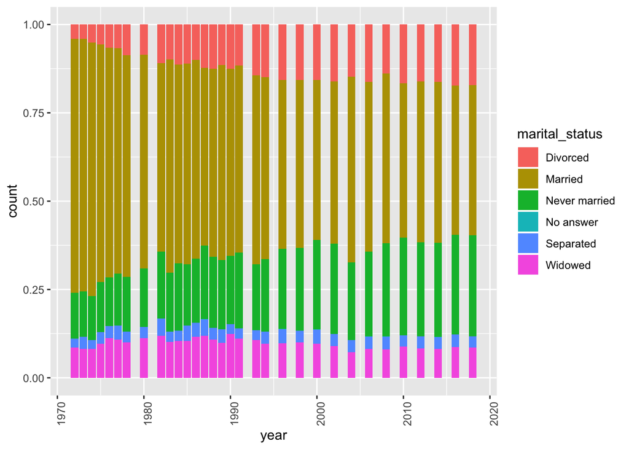

```r
plt <- ggplot(data=dat,  aes(x=year, fill=marital_status)) # assigning graph
pltNew <- plt + geom_bar(position="fill") # assigning new graph
pltNew + theme(axis.text.x=element_text(angle=90, hjust=1)) # rotating the x-axis labels 90 degrees
```

# 4.2)

How does is Political Affiliation affected by the year?

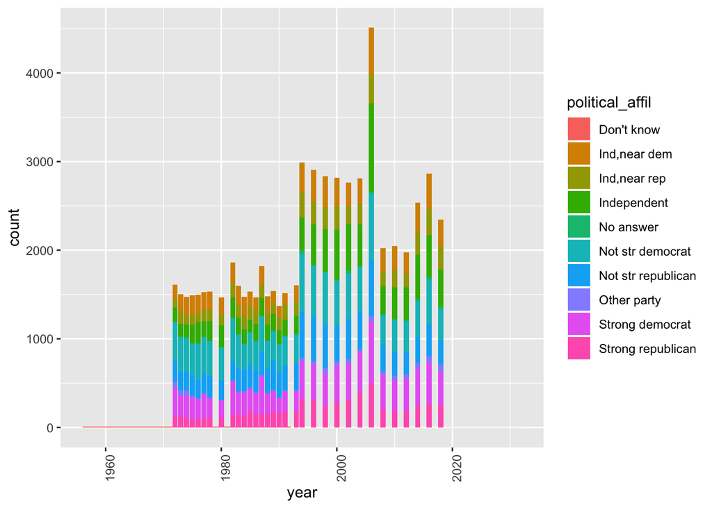

```r
plt <- ggplot(data=dat,  aes(x=year, fill=political_affil)) # assigning graph
pltNew <- plt + geom_bar() # assigning new graph
pltNew + theme(axis.text.x=element_text(angle=90, hjust=1)) # rotating the x-axis labels 90 degrees
```

# 4.3)

How does sex affect political affiliation? Is there a trend between male and female, and their respective political affiliations?

From this fractional bar chart we can see that Not strong democrats and Strong democrats are female dominated. On the other hand, the other party appears to be male dominated. For the most part the rest of the political affiliations appear to have near equal sex distrubtion.

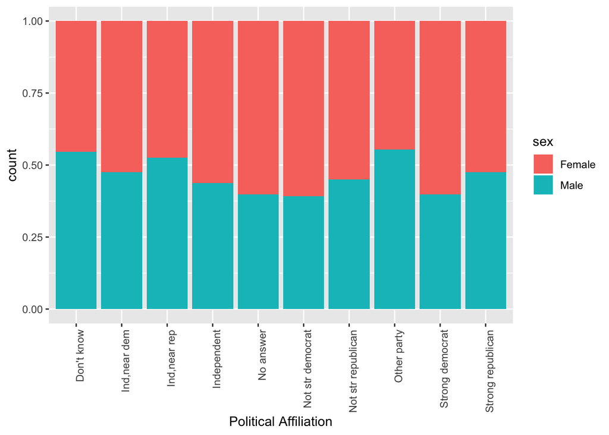

```r
dat4 <- dat[!is.na(dat$`sex`), ]
plt4 <- ggplot(data = dat4, aes(x=political_affil, fill=sex)) + geom_bar(position="fill")
plt4+theme(axis.text.x=element_text(angle=90, hjust=1))+xlab("Political Affiliation") # Rotate 90 degrees
```

# 4.4)

How does the marital status affect the political affiliation?

From this fractional stacked bar graph we can see that republican affiliation has the largest fraction of married couples. While democratic affiliation has the largest fraction of divorced, never married, separated, and widowed. This means that some viewpoint of the democratic supporters causes individuals to deviate from the traditional marital roles.

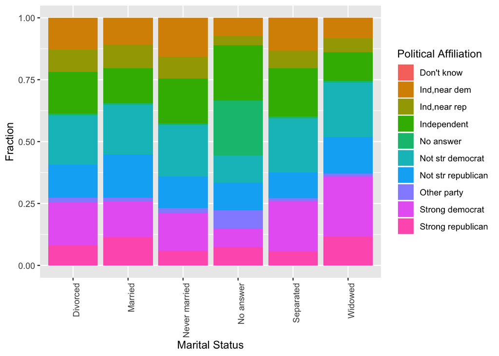

```r
dat4 <- dat[!is.na(dat$`happiness`), ]
dat4 <- dat4[!is.na(dat4$`political_affil`), ]
plt <- ggplot(data=dat4,  aes(x=marital_status, fill=political_affil)) # assigning graph
pltNew <- plt + geom_bar(position="fill") # assigning new graph
pltNew + theme(axis.text.x=element_text(angle=90, hjust=1))+xlab("Marital Status") + labs(fill = "Political Affiliation") + ylab("Fraction")
```

```r
# rotating the x-axis labels 90 degrees
```